# StatData 1: om grafik i R

Der er rigtig gode muligheder for at producere professionel grafik i R. Det forventes ikke, at I kan lave andet end de få standardfigurer, som optræder ved forelæsningerne. Det drejer sig om

- scatterplot
- histogrammer
- QQ-plot
- Boxplot

Hen over hele undervisningsmaterialet vil det som udgangspunkt være illustreret, hvordan man kan lave figurerne med to typer af R værktøjer

- med funktioner der følger med standardinstallationen i R
- med funktioner i R pakken `ggplot2` (der bl.a. loades hvis man henter `tidyverse` med kommandoen `library(tidyverse)`)

Formålet med dette dokument er at give den interesserede StatData1-studerende bedre forudsætninger for at lære at lave grafik med R.

Vi starter med at indlæse to datasæt, som benyttes til illustration

- `cats` fra `MASS` R-pakken: indeholder målinger af kropsvægt (i kg) og hjertevægt (i g) for 144 katte
- `antibio` fra `isdals` R-pakken: indeholder målinger af indholdet af organisk stof i gødning fra kvier som har modtaget foder med forskellige typer af antibiotika

```r
library(MASS) ### indeholder datasættet 'cats'
library(isdals) ### indeholder alle datasæt benyttet i lærebogen
data(antibio)
```

# Standardgrafik

## Scatterplot

Simpel R kode til at producere scatterplot af hjertevægt mod kropsvægt for de 144 katte i datasættet `cats`

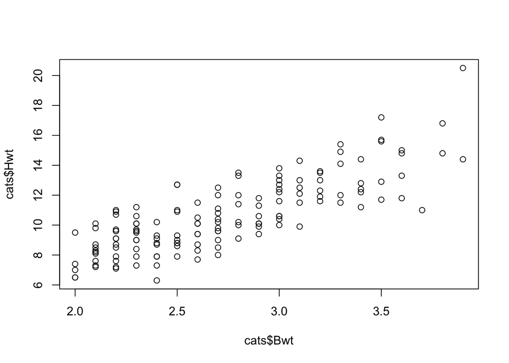

```r
plot(cats$Bwt, cats$Hwt)
```

R-koden nedenfor viser hvordan man kan

- ændre teksten på akserne
- tilføje en overskrift
- ændre plot-symbolet (prøv selv med andre værdier af `pch`)
- farven af plot-symbolerne
- hvilke intervaller af x- og y-værdier der skal vises på figuren
- tilføje en ret linje (med skæring og hældning fundet ved lineær regression tidl. på kurset)

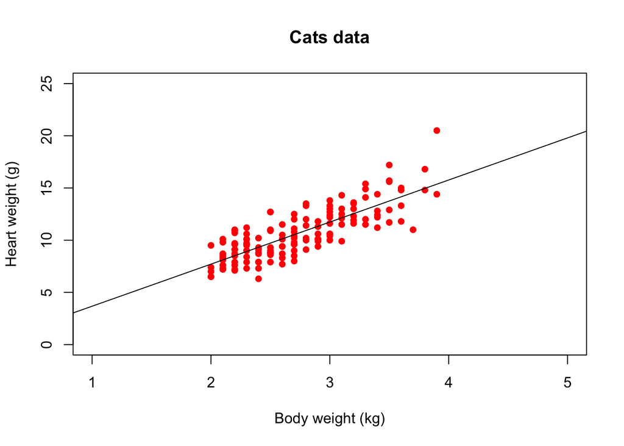

```r
plot(cats$Bwt, cats$Hwt, xlab = "Body weight (kg)",  ylab = "Heart weight (g)"
     , main = "Cats data", pch = 16, col = "red"
     , ylim = c(0, 25), xlim = c(1, 5))
abline(-0.3567, 4.0314)
```

## Histogrammer

Der findes del information om, hvordan man kan lave histogrammer i R programmet fra første forelæsning

Simpel R kode til at lave histogrammer for hjertevægt (`Hwt`) og kropsvægt (`Bwt`) findes her

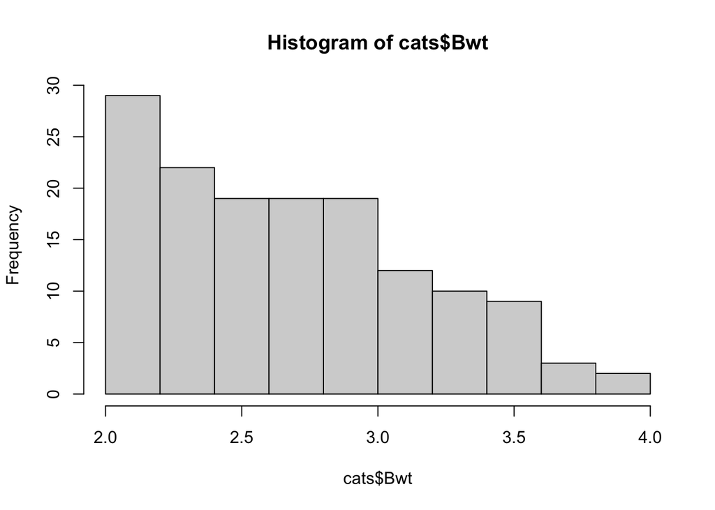

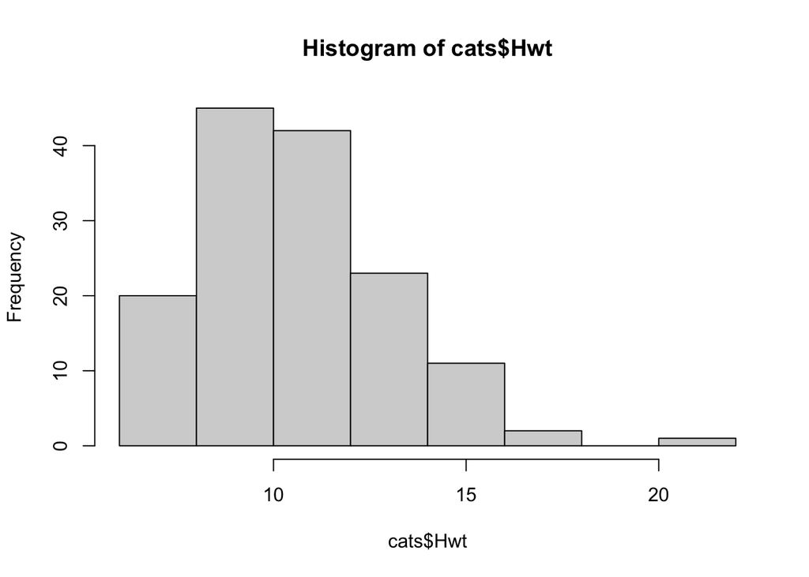

```r
hist(cats$Bwt)
hist(cats$Hwt)
```

R koden neden for viser hvordan man kan sørge for at

- der benyttes 20 søjler
- søjlerne farves lysegrå
- der sættes labels på x-aksen
- der sættes en overskrift på figuren
- det samlede areal under boksene skaleres til at være 1 (dvs. 100 %)

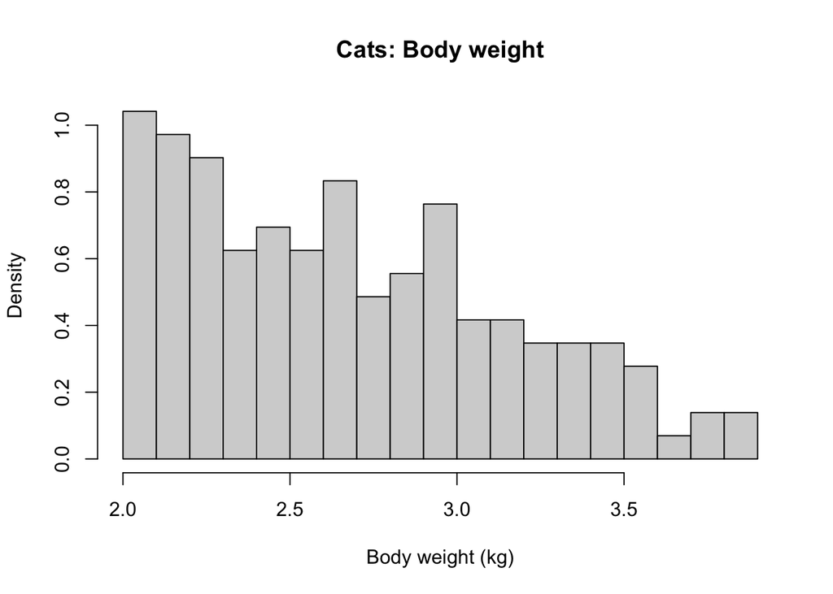

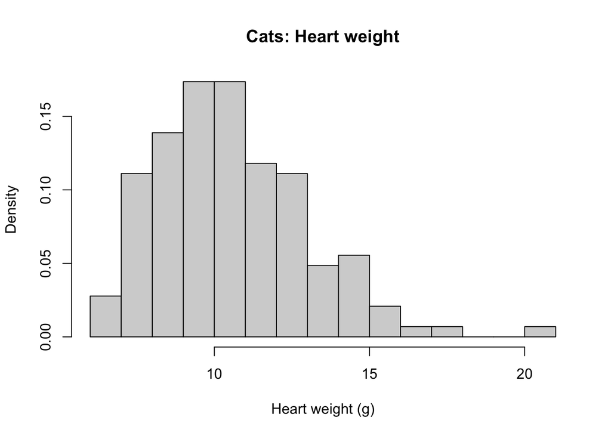

```r
hist(cats$Bwt, xlab="Body weight (kg)", main="Cats: Body weight", nclass=20, prob=TRUE, col = "lightgray")
hist(cats$Hwt, xlab="Heart weight (g)", main="Cats: Heart weight", nclass=20, prob=TRUE, col = "lightgray")
```

## Boxplot

Simpel R-kode til at producere et boxplot af indholdet af organisk stof i hver af de 6 fodergrupper fra datasættet `antibio` i `isdals` R-pakken

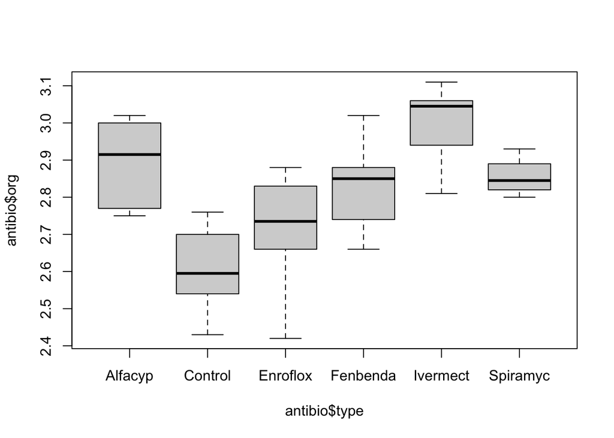

```r
boxplot(antibio$org ~ antibio$type)
```

# Grafik med R-pakken `ggplot2`

Det kræver lidt øvelse at forstå logikken, når man skal producere grafik i R ved brug af `ggplot2` R-pakken. Det er bl.a. nyttigt at vide at

- en figur opbygges ved at tilføje forskellige lag/komponenter (adskilt med symbolet `+` i R-koden)
- hver type figur produceres med en bestemt type funktion (kaldet en `geom`) og man bør google hvilke *options* (kaldet: *aestetics*) der hører til de forskellige typer af figurer
- i praksis laver man en bestemt type figur (`geom`) ved at fortælle hvilke variable fra det relevante datasæt, som skal afbildes (*mappes*) til de forskellige komponenter (*aestetics*) på figuren

Det er særdeles nyttigt at google sig frem til gode eksempler, når man skal lave figurer med `ggplot2`. Når man er kommet godt igang, så kan følgende [cheat sheet](https://www.rstudio.com/wp-content/uploads/2015/03/ggplot2-cheatsheet.pdf) være til stor hjælp.

## Scatterplot

Simpel R kode til at producere scatterplot af hjertevægt mod kropsvægt for de 144 katte i datasættet `cats`

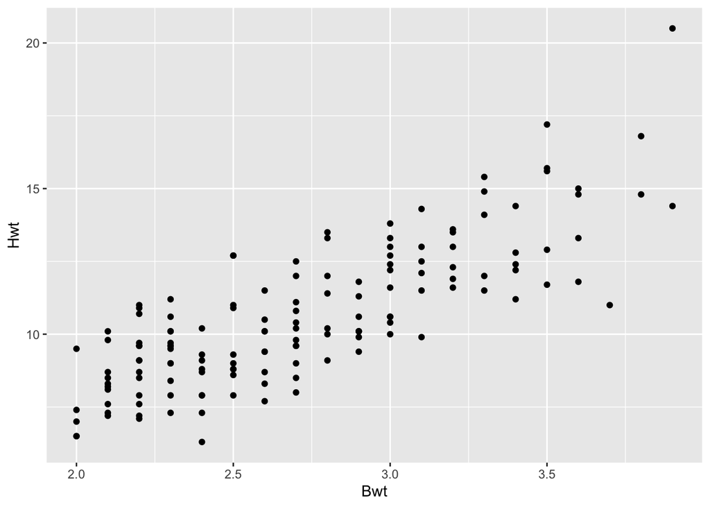

```r
ggplot(data = cats) + geom_point(aes(x = Bwt, y = Hwt))
```

**Forklaring:** Scatterplot laves med funktionen `geom_point`. Et scatterplot er en visualisering af to kontinuerte variable imod hinanden, og for at lave et scatterplot skal man som minimum angive, hvilke variable der skal være på `x` hhv. `y` aksen. I `ggplot2` syntaks siger man, at vi angiver hvilke variable fra datasættet, som skal *mappes* til `x` og `y` *aestetics* hørende til `geom_point()` funktionen. På figuren ovenfor er det datasættet `cats` som afbildes på et scatterplot ved at variablene `Bwt` og `Hwt` *mappes* til `x` og `y`.

Følgende [link](https://ggplot2.tidyverse.org/articles/ggplot2-specs.html) giver en detaljeret oversigt over, hvordan man kontrollerer nogle af de vigtigste `aestetics` som benyttes i forbindelse med `ggplot2`.

Nedenfor findes et antal eksempler på, hvordan man kan ændre udseendet af scatterplottet ved at ændre forskellige andre *aestetics* hørende til `geom_point()` funktionen. Prøv selv at eksperimenter med at ændre og fjerne forskellige komponenter på figuren ved at modificere R-koden.

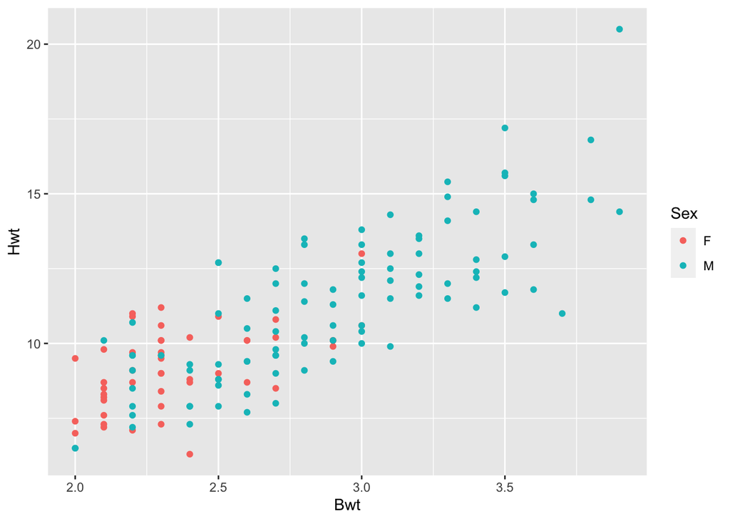

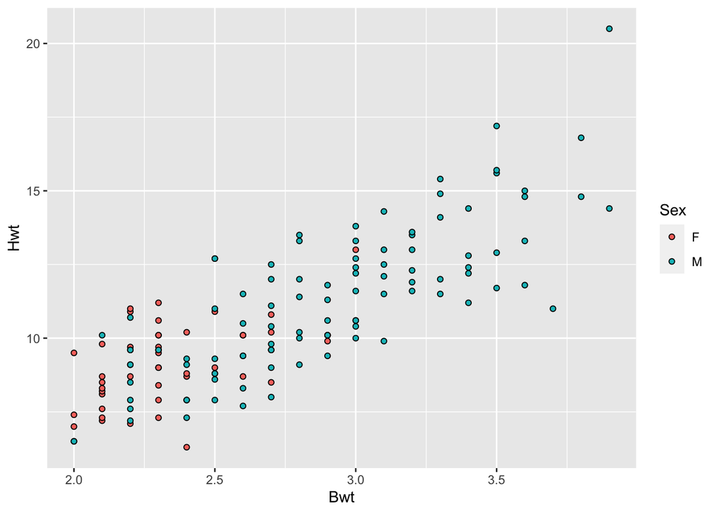

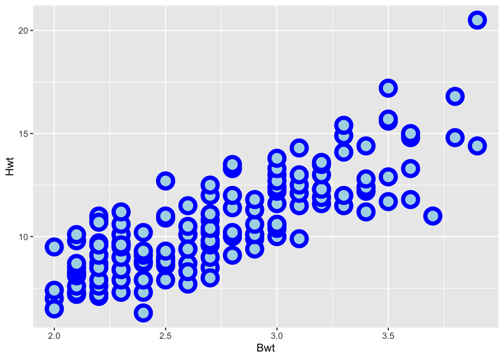

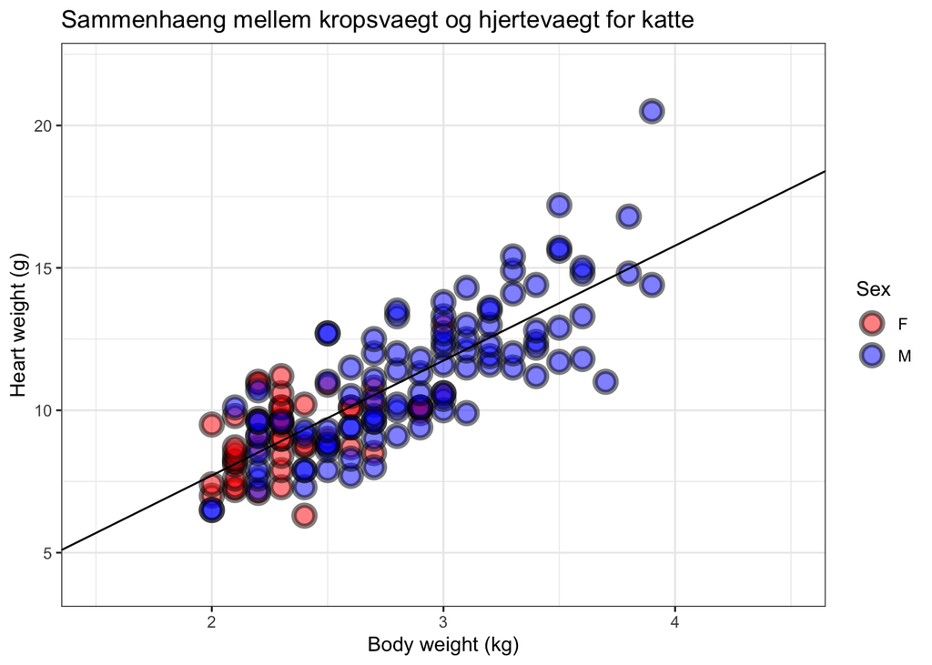

```r
ggplot(data = cats) + geom_point(aes(x = Bwt, y = Hwt, color = Sex))

ggplot(data = cats) + geom_point(aes(x = Bwt, y = Hwt, fill = Sex), shape = 21)

ggplot(data = cats) + geom_point(aes(x = Bwt, y = Hwt), alpha = 1, colour = "blue", fill = "lightblue"
                                 , shape = 21
                                 , size = 5
                                 , stroke = 3)

ggplot(data = cats) + geom_point(aes(x = Bwt, y = Hwt, fill = Sex), shape = 21, size = 4, stroke = 2, alpha = 0.5) + labs(x = "Body weight (kg)", y = "Heart weight (g)") +
  lims(x = c(1.5, 4.5), y = c(4, 22)) +
  scale_fill_manual(values = c("F" = "red", "M" = "blue")) +
 theme_bw() +  ggtitle("Sammenhaeng mellem kropsvaegt og hjertevaegt for katte") +
  geom_abline(intercept = -0.3567, slope = 4.0341)
```

## Histogrammer

Simpel R kode til at lave histogrammer for hjertevægt (Hwt) og kropsvægt (Bwt) findes her

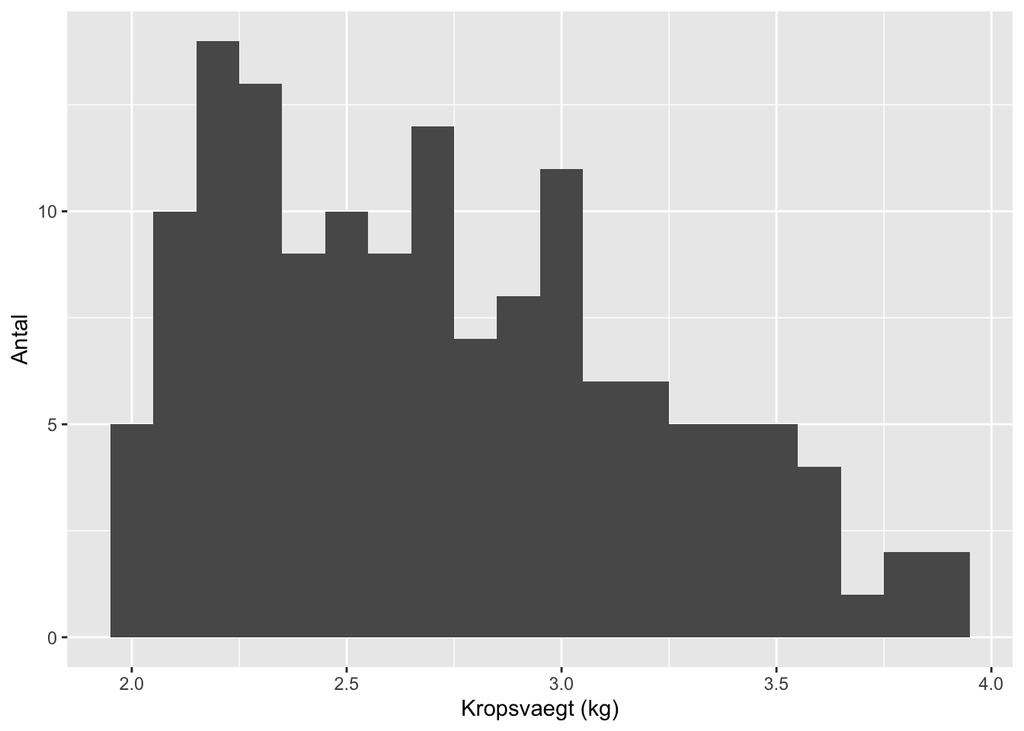

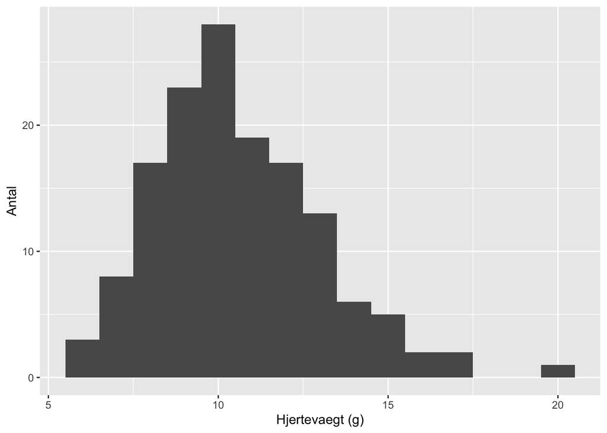

```r
ggplot(data = cats) + geom_histogram(aes(x = Bwt), binwidth = 0.1) +
  labs(x = "Kropsvaegt (kg)", y = "Antal")
ggplot(data = cats) + geom_histogram(aes(x = Hwt), binwidth = 1) +
  labs(x = "Hjertevaegt (g)", y = "Antal")
```

**Forklaring:** Et histogram laves med funktionen `geom_histogram`. Et histogram viser andelen af observationer som falder i givne intervaller (eng: *bins*). Antallet af observationer i hvert interval visualiseres ved en *kasse/søjle*. Man skal som minimum angive, hvilken variabel (`x`) der skal optegnes på histogrammmet. I koden ovenfor har vi også valgt bredden (`binwidth`) af søjlerne på histogrammet og sat navne på akserne.

## Boxplot

Simpel R-kode til at producere et boxplot af indholdet af organisk stof i hver af de 6 fodergrupper fra datasættet `antibio` i `isdals` R-pakken.

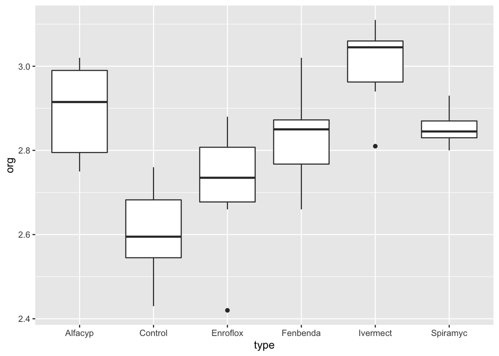

```r
ggplot(data = antibio) + geom_boxplot(aes(x = type, y = org))
```

**Forklaring:** Boxplot laves med funktionen `geom_boxplot`. Et boxplot visualiserer primært fraktilerne for en kontinuert variable typisk opdelt efter grupper givet ved en kategorisk variabel. Man skal derfor som minimum angive, hvilken variabel der skal afbildes (`y`) samt hvilken kategorisk variabel (`x`) i datasættet der repræsenterer den relevant opdeling af datasættet i grupper.

Prøv selv at forklare hvad der sker, hvis du fjerner `x = type` fra R-koden ovenfor.

Nedenfor vises eksempler på, hvordan man kan ændre på boxplottet.

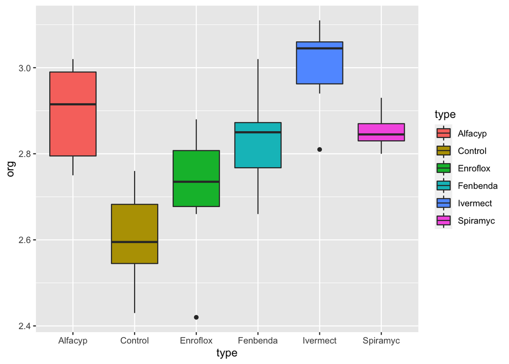

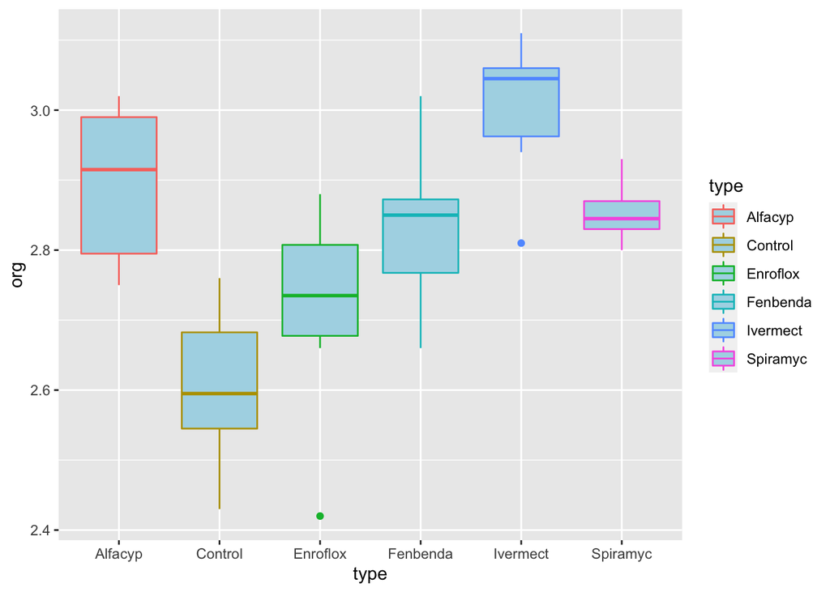

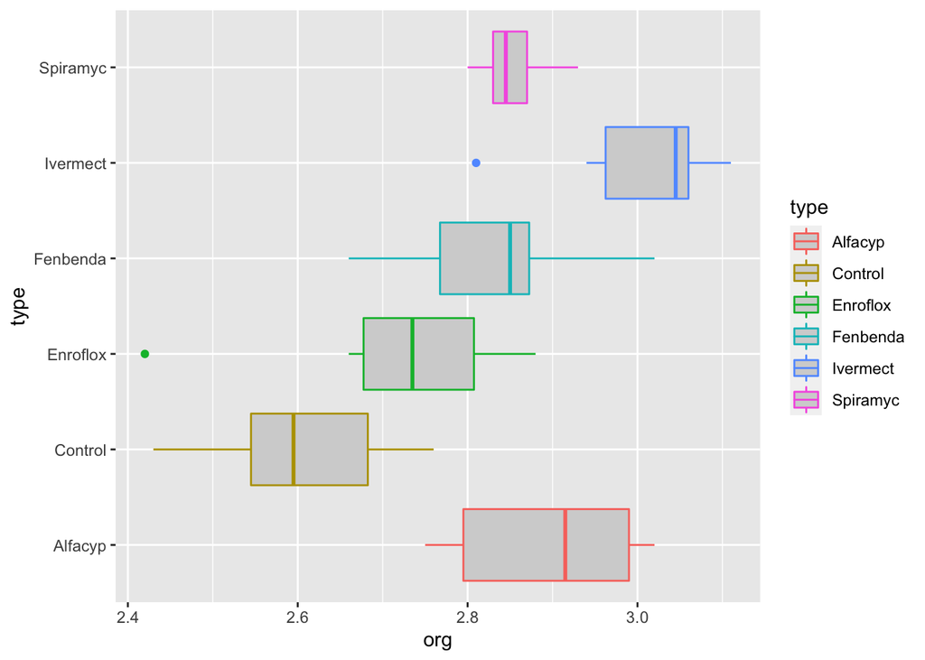

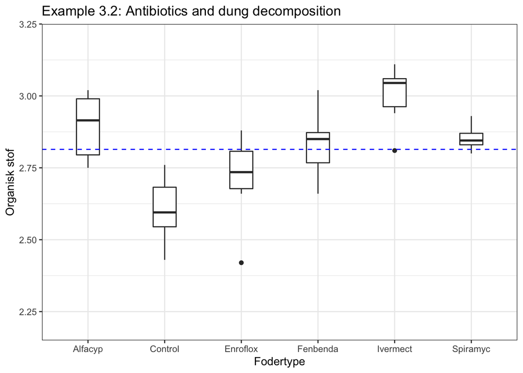

```r
ggplot(data = antibio) + geom_boxplot(aes(x = type, y = org, fill = type))

ggplot(data = antibio) + geom_boxplot(aes(x = type, y = org, color = type), fill = "lightblue", linetype = 1)

ggplot(data = antibio) + geom_boxplot(aes(x = type, y = org, color = type), fill = "lightgrey") + coord_flip()

ggplot(data = antibio) + geom_boxplot(aes(x = type, y = org), width = 0.3) +
  labs(x = "Fodertype", y = "Organisk stof", title = "Example 3.2: Antibiotics and dung decomposition") + theme_bw() + lims(y = c(2.2, 3.2)) +
  geom_hline(yintercept = mean(antibio$org), linetype = 2, color = "blue")
```